# Time Series Analysis - Homework #2

Luke Schwenke

2023-07-03

# Question 1

Load the visitors.rda dataset, make a time plot of your data and describe the main features of the series

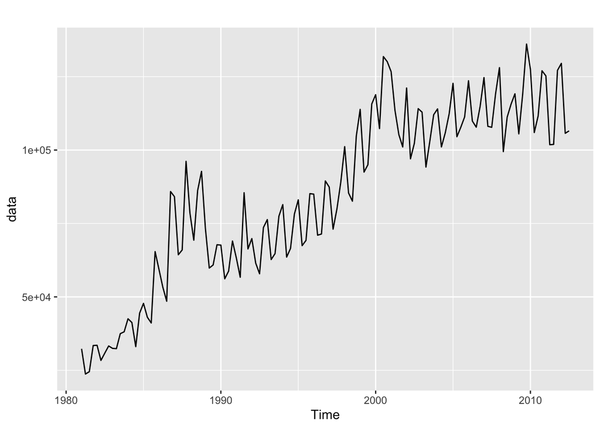

```r
load('visitors.rda')
data <- ts(visitors[c("Arrivals")], frequency = 4,
           start = c(1981, 1), end = c(2012,3))

autoplot(data)
```

# Question 2

What is the appropriate Holt-Winters method for this data set (multiplicative / additive)? Why?

**Answer:** The appropriate Holt-Winters method is multiplicative because the seasonal decomposition chart is more stable between 0.95 and 1.05. This indicates a seasonal variation increases (multiplies) over time.

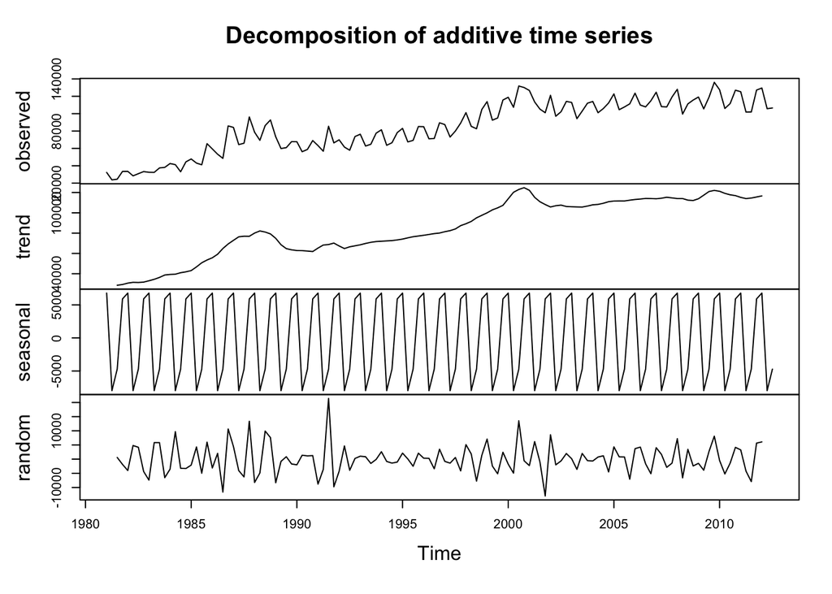

```r
# Additive Decomposition
decompose(data, type='additive') %>% plot()
```

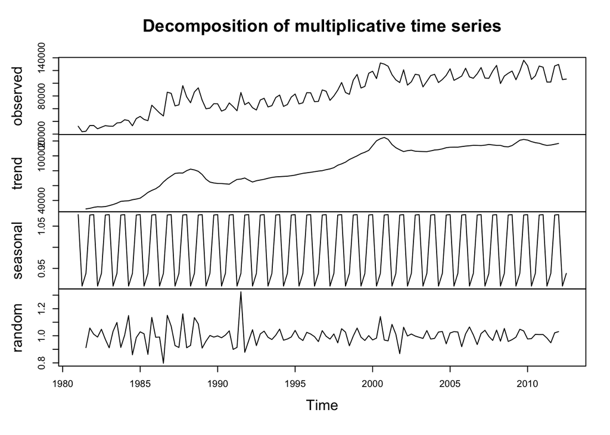

```r
# Multiplicative Decomposition
decompose(data, type='multiplicative') %>% plot()
```

# Question 3

Use the hw() function to forecast the next 24 months using Holt-Winters’ methods. Experiment with the following methods

- Linear trend with additive seasonality
- Linear trend with multiplicative seasonality
- Linear trend with additive seasonality and damping
- Linear trend with multiplicative seasonality and damping

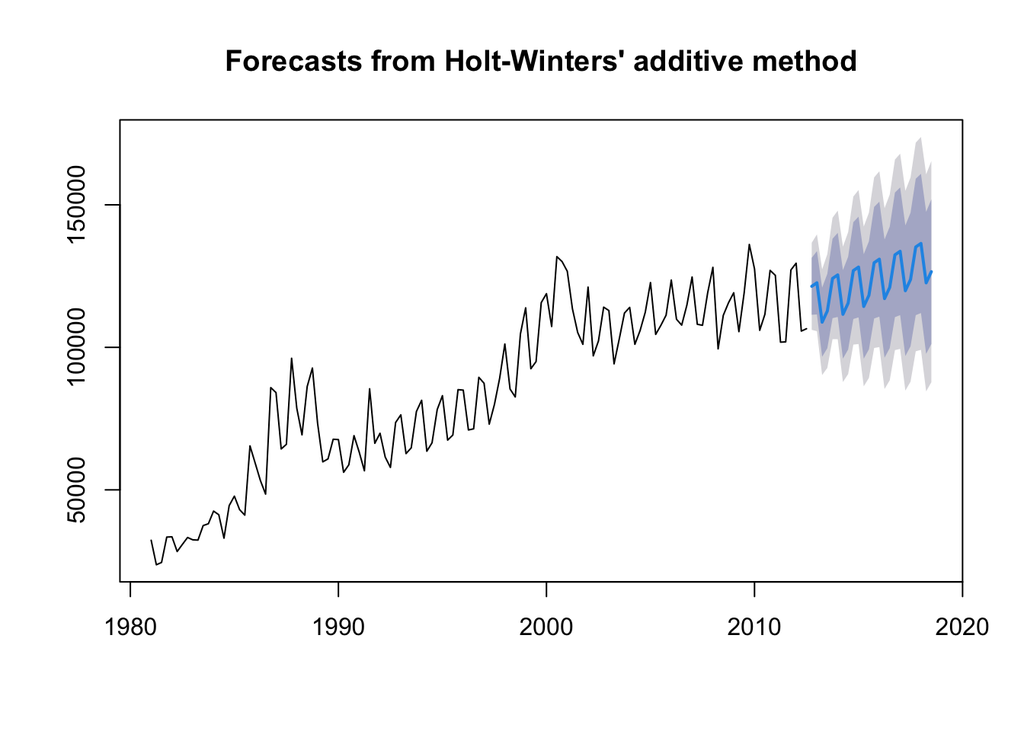

```r
add <- hw(y=data, h=24, seasonal = 'additive')

mult <- hw(y=data, h=24, seasonal = 'multiplicative')

add_damp <- hw(y=data, h=24, seasonal = 'additive', damped=TRUE)

mult_damp <- hw(y=data, h=24, seasonal = 'multiplicative', damped=TRUE)

plot(add)
```

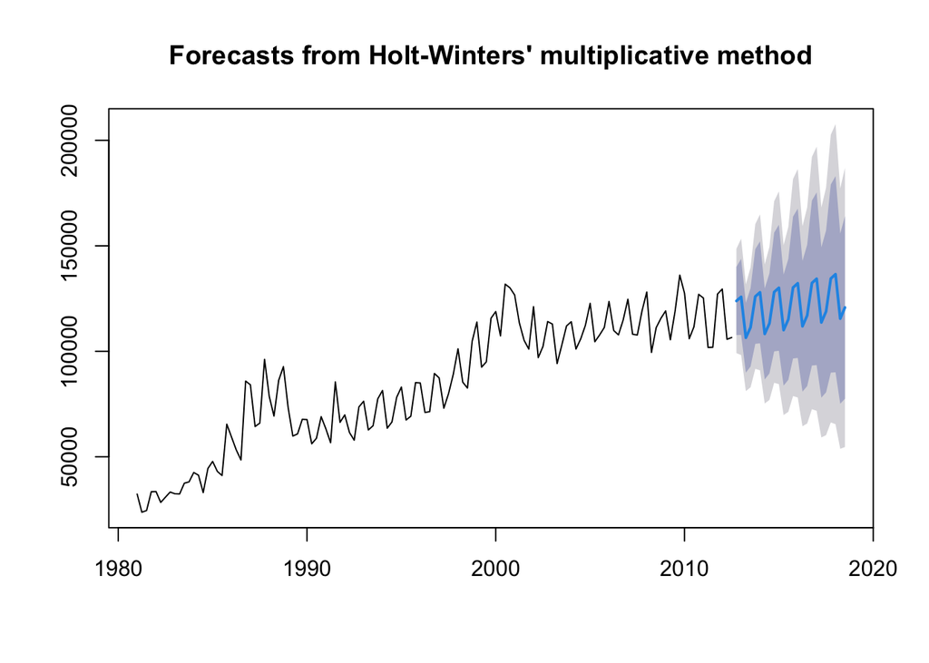

```r
plot(mult)
```

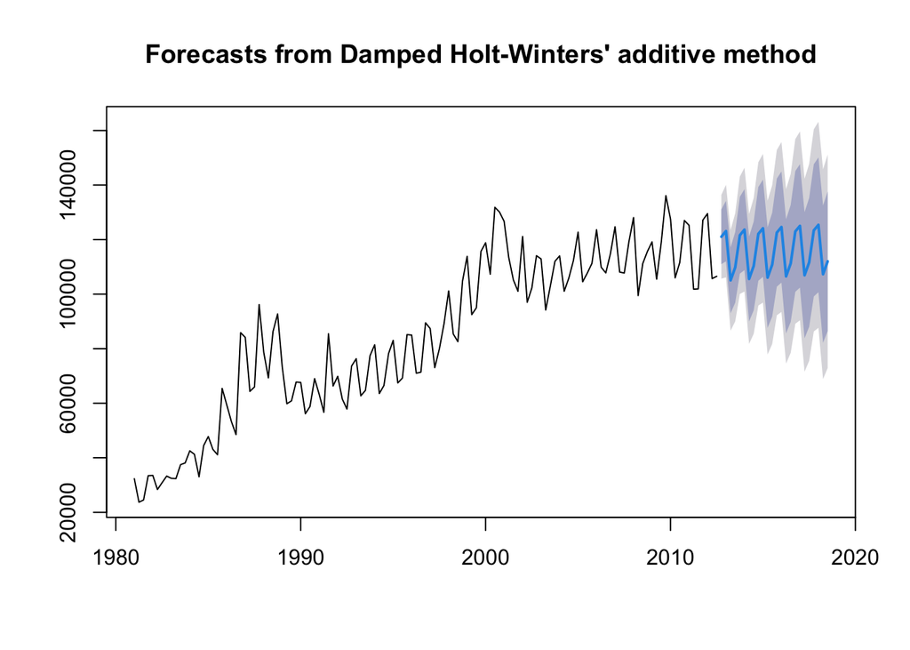

```r
plot(add_damp)
```

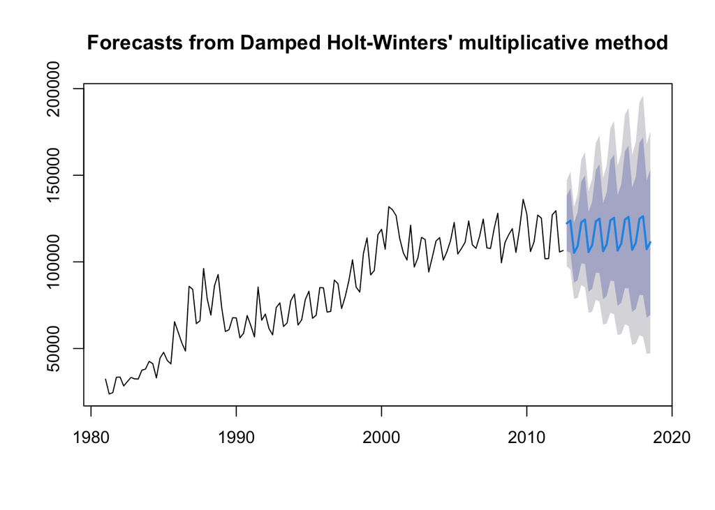

```r
plot(mult_damp)
```

# Question 4

Use the accuracy() function to compare the Root-Mean-Square-Error (RMSE) values of the forecasts from the various methods. Which do you prefer and why?

```r
paste('Additive RMSE:', accuracy(add)[2])
```

```
## [1] "Additive RMSE: 7542.65568342107"
```

```r
paste('Multiplicative RMSE:', accuracy(mult)[2])
```

```
## [1] "Multiplicative RMSE: 7550.9560612106"
```

```r
paste('Additive with Damping RMSE:', accuracy(add_damp)[2])
```

```
## [1] "Additive with Damping RMSE: 7552.06372903439"
```

```r
paste('Multiplicative with Damping RMSE:', accuracy(mult_damp)[2])
```

```
## [1] "Multiplicative with Damping RMSE: 7460.00153236291"
```

**Answer:** I prefer the Multiplicative Seasonality with Damping model because it has the smallest RMSE value at 7460. The multiplicative aspect makes sense as I stated above that there is a multiplying factor on seasonality over time. The dampening helps reduce the magnitude of future seasonal variations as the forecast extends – in this instance this helps reduce the RMSE.

# Question 5

Use the checkresiduals() function to check that the residuals from the best model look like white noise and provide a summary of the model’s smoothing parameters using the summary() function.

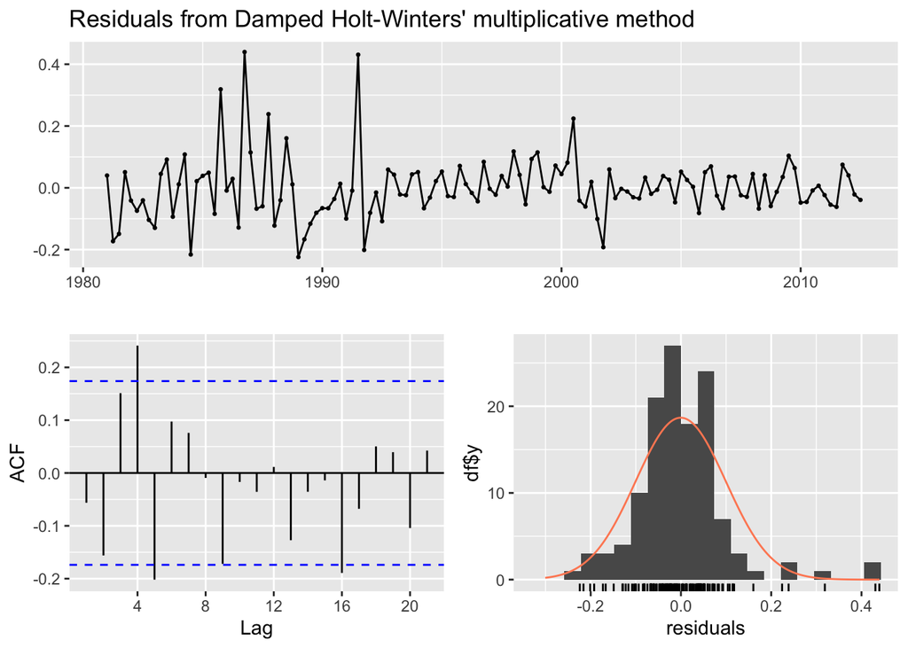

```
##
##  Ljung-Box test
##
## data:  Residuals from Damped Holt-Winters' multiplicative method
## Q* = 21.921, df = 8, p-value = 0.005064
##
## Model df: 0.   Total lags used: 8
```

```r
checkresiduals(mult_damp)
```

```r
summary(mult_damp)
```

```
##
## Forecast method: Damped Holt-Winters' multiplicative method
##
## Model Information:
## Damped Holt-Winters' multiplicative method
##
## Call:
##  hw(y = data, h = 24, seasonal = "multiplicative", damped = TRUE)
##
##   Smoothing parameters:
##     alpha = 0.52
##     beta  = 0.0027
##     gamma = 1e-04
##     phi   = 0.98
##
##   Initial states:
##     l = 26914.2591
##     b = 2002.8599
##     s = 1.0638 0.9467 0.9133 1.0762
##
##   sigma:  0.1034
##
##      AIC     AICc      BIC
## 2913.642 2915.538 2942.084
##
## Error measures:
##                     ME     RMSE     MAE        MPE     MAPE      MASE
## Training set -1.834419 7460.002 5363.22 -0.9701216 6.852661 0.7266756
##                      ACF1
## Training set -0.001971966
##
## Forecasts:
##         Point Forecast     Lo 80    Hi 80    Lo 95    Hi 95
## 2012 Q4       122225.2 106033.32 138417.1 97461.86 146988.5
## 2013 Q1       123798.8 105276.90 142320.8 95471.97 152125.7
## 2013 Q2       105187.4  87816.96 122557.8 78621.62 131753.1
## 2013 Q3       109171.5  89578.75 128764.3 79206.97 139136.1
## 2013 Q4       122829.1  99138.55 146519.6 86597.54 159060.7
## 2014 Q1       124397.5  98830.37 149964.7 85295.93 163499.2
## 2014 Q2       105685.3  82691.88 128678.6 70519.92 140850.6
## 2014 Q3       109677.3  84552.31 134802.3 71251.94 148102.7
## 2014 Q4       123386.1  93754.23 153018.0 78068.05 168704.2
## 2015 Q1       124949.8  93607.44 156292.1 77015.81 172883.7
## 2015 Q2       106144.5  78421.35 133867.7 63745.60 148543.4
## 2015 Q3       110143.9  80270.02 140017.7 64455.77 155832.0
## 2015 Q4       123899.9  89083.75 158716.1 70653.18 177146.7
## 2016 Q1       125459.1  89009.06 161909.2 69713.57 181204.7
## 2016 Q2       106568.1  74614.21 138522.0 57698.83 155437.4
## 2016 Q3       110574.2  76411.57 144736.8 58326.96 162821.4
## 2016 Q4       124373.9  84836.81 163910.9 63907.17 184840.6
## 2017 Q1       125929.0  84794.32 167063.6 63018.96 188838.9
## 2017 Q2       106958.8  71100.32 142817.3 52117.97 161799.7
## 2017 Q3       110971.1  72828.41 149113.8 52636.88 169305.4
## 2017 Q4       124811.0  80871.39 168750.6 57611.16 192010.8
## 2018 Q1       126362.3  80839.83 171884.8 56741.68 195982.9
## 2018 Q2       107319.2  67789.06 146849.4 46863.05 167775.4
## 2018 Q3       111337.2  69438.65 153235.8 47258.88 175415.6
```

**Answer:** The smoothing parameters of the best performing model (Multiplicative with Damping) are as follows:

- alpha = 0.52
- beta = 0.0027
- gamma = 1e-04
- phi = 0.98

The residuals show signs of not being white noise. This is because there are some slight patterns in the plot. Additionally the ACF plot shows some significance at various lags, specifically 4, 5, 16. The residual plot is also not evenly distributed. The Ljung-Box test’s small p-value tells us to reject the null hypothesis and conclude autocorrelation exists and the residuals are not white noise. Though this was the best of the 4 models ran, we can assume there is information left in the residuals that should be used in computing forecasts and improvements can be made to the predictive model.

# Question 6

Use the snaive() function to forecast the next 24 months, and the accuracy() function to evaluate the model. Did your best model beat the seasonal naïve approach?

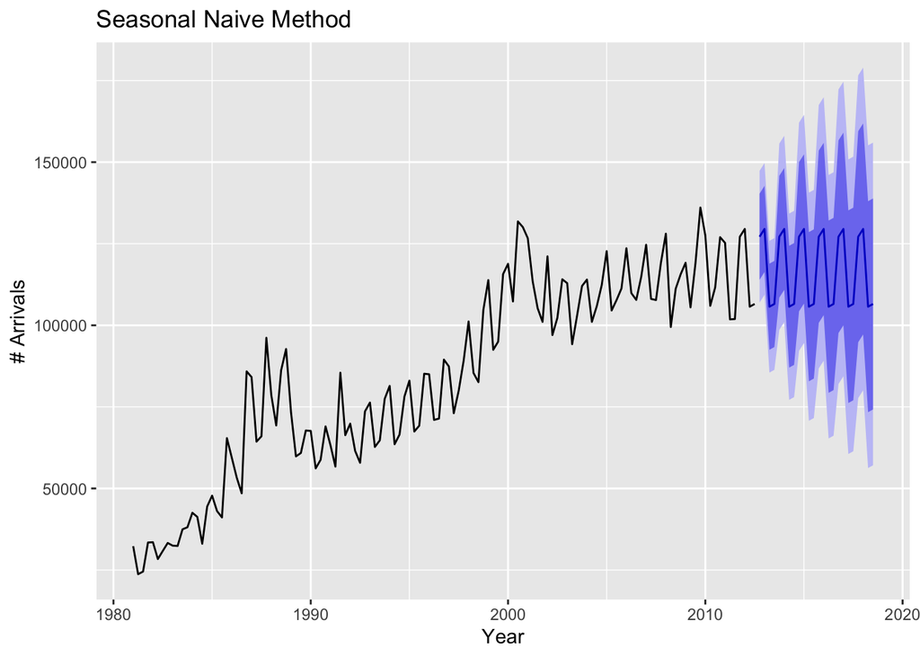

```r
seasonal_naive <- snaive(y=data, h=24)

autoplot(seasonal_naive) +
  labs(x="Year", y="# Arrivals", title="Seasonal Naive Method")
```

```r
paste("Seasonal Naive RMSE:", accuracy(seasonal_naive)[2])
```

```
## [1] "Seasonal Naive RMSE: 10298.9849101191"
```

```r
paste("Best Performing Model RMSE:", accuracy(mult_damp)[2])
```

```
## [1] "Best Performing Model RMSE: 7460.00153236291"
```

```r
accuracy(mult_damp)[2] - accuracy(seasonal_naive)[2]
```

```
## [1] -2838.983
```

**Answer:** My best performing Multiplicative with Dampening model (RMSE = 7,460) performed better than the naive method (RMSE = 10,298) with a difference of 2,838.